# What makes for a successful Kickstarter Project?

```r
library(doSNOW)
```

# Data Manipulation

The classes of some categories need to be changed. Columns that should be factors: category, main_category, currency, state, country. Columns that should be character vectors: ID

```r
glimpse(ks2018)
```

```
Observations: 378,661
Variables: 15
$ ID               <int> 1000002330, 1000003930, 100000403...
$ name             <chr> "The Songs of Adelaide & Abullah"...
$ category         <chr> "Poetry", "Narrative Film", "Narr...
$ main_category    <chr> "Publishing", "Film & Video", "Fi...
$ currency         <chr> "GBP", "USD", "USD", "USD", "USD"...
$ deadline         <date> 2015-10-09, 2017-11-01, 2013-02-...
$ goal             <dbl> 1000, 30000, 45000, 5000, 19500, ...
$ launched         <dttm> 2015-08-11 12:12:28, 2017-09-02 ...
$ pledged          <dbl> 0.00, 2421.00, 220.00, 1.00, 1283...
$ state            <chr> "failed", "failed", "failed", "fa...
$ backers          <int> 0, 15, 3, 1, 14, 224, 16, 40, 58,...
$ country          <chr> "GB", "US", "US", "US", "US", "US...
$ `usd pledged`    <dbl> 0.00, 100.00, 220.00, 1.00, 1283....
$ usd_pledged_real <dbl> 0.00, 2421.00, 220.00, 1.00, 1283...
$ usd_goal_real    <dbl> 1533.95, 30000.00, 45000.00, 5000...
```

```r
summary(ks2018)
```

```
       ID                name             category
 Min.   :5.971e+03   Length:378661      Length:378661
 1st Qu.:5.383e+08   Class :character   Class :character
 Median :1.075e+09   Mode  :character   Mode  :character
 Mean   :1.075e+09
 3rd Qu.:1.610e+09
 Max.   :2.147e+09

 main_category        currency            deadline
 Length:378661      Length:378661      Min.   :2009-05-03
 Class :character   Class :character   1st Qu.:2013-06-08
 Mode  :character   Mode  :character   Median :2015-01-14
                                       Mean   :2014-11-01
                                       3rd Qu.:2016-04-28
                                       Max.   :2018-03-03

      goal              launched
 Min.   :        0   Min.   :1970-01-01 01:00:00
 1st Qu.:     2000   1st Qu.:2013-05-07 22:14:27
 Median :     5200   Median :2014-12-10 03:23:41
 Mean   :    49081   Mean   :2014-09-28 18:06:17
 3rd Qu.:    16000   3rd Qu.:2016-03-24 10:21:09
 Max.   :100000000   Max.   :2018-01-02 15:02:31

    pledged            state              backers
 Min.   :       0   Length:378661      Min.   :     0.0
 1st Qu.:      30   Class :character   1st Qu.:     2.0
 Median :     620   Mode  :character   Median :    12.0
 Mean   :    9683                      Mean   :   105.6
 3rd Qu.:    4076                      3rd Qu.:    56.0
 Max.   :20338986                      Max.   :219382.0

   country           usd pledged       usd_pledged_real
 Length:378661      Min.   :       0   Min.   :       0
 Class :character   1st Qu.:      17   1st Qu.:      31
 Mode  :character   Median :     395   Median :     624
                    Mean   :    7037   Mean   :    9059
                    3rd Qu.:    3034   3rd Qu.:    4050
                    Max.   :20338986   Max.   :20338986
                    NA's   :3797
 usd_goal_real
 Min.   :        0
 1st Qu.:     2000
 Median :     5500
 Mean   :    45454
 3rd Qu.:    15500
 Max.   :166361391
```

I copied the dataframe as to not edit the original import.

```r
ks18_1 <- ks2018
```

I change the required columns into factors and checked this has worked.

```r
factor_names <- c("category", "main_category", "currency", "state", "country")
glimpse(ks18_1[factor_names])
```

```
Observations: 378,661
Variables: 5
$ category      <chr> "Poetry", "Narrative Film", "Narrati...
$ main_category <chr> "Publishing", "Film & Video", "Film ...
$ currency      <chr> "GBP", "USD", "USD", "USD", "USD", "...
$ state         <chr> "failed", "failed", "failed", "faile...
$ country       <chr> "GB", "US", "US", "US", "US", "US", ...
```

```r
ks18_1[factor_names] <- lapply(ks18_1[factor_names], factor)
glimpse(ks18_1[factor_names])
```

```
Observations: 378,661
Variables: 5
$ category      <fct> Poetry, Narrative Film, Narrative Fi...
$ main_category <fct> Publishing, Film & Video, Film & Vid...
$ currency      <fct> GBP, USD, USD, USD, USD, USD, USD, U...
$ state         <fct> failed, failed, failed, failed, canc...
$ country       <fct> GB, US, US, US, US, US, US, US, US, ...
```

Then I changed the ID column from an integer vector to a character vector and checked this has worked.

```r
glimpse(ks18_1$ID)
```

```
 int [1:378661] 1000002330 1000003930 1000004038 1000007540 1000011046 1000014025 1000023410 1000030581 1000034518 100004195 ...
```

```r
ks18_1$ID <- as.character(ks18_1$ID)
glimpse(ks18_1$ID)
```

```
 chr [1:378661] "1000002330" "1000003930" "1000004038" ...
```

I checked for missing values. usd_pledged is the only category of interest with NAs (1%). I will ignore this because I have chosen to use the usd_pledged_real column for my analysis.

```r
summary(ks18_1)
```

```
      ID                name                     category
 Length:378661      Length:378661      Product Design: 22314
 Class :character   Class :character   Documentary   : 16139
 Mode  :character   Mode  :character   Music         : 15727
                                       Tabletop Games: 14180
                                       Shorts        : 12357
                                       Video Games   : 11830
                                       (Other)       :286114
      main_category       currency         deadline
 Film & Video: 63585   USD    :295365   Min.   :2009-05-03
 Music       : 51918   GBP    : 34132   1st Qu.:2013-06-08
 Publishing  : 39874   EUR    : 17405   Median :2015-01-14
 Games       : 35231   CAD    : 14962   Mean   :2014-11-01
 Technology  : 32569   AUD    :  7950   3rd Qu.:2016-04-28
 Design      : 30070   SEK    :  1788   Max.   :2018-03-03
 (Other)     :125414   (Other):  7059
      goal              launched
 Min.   :        0   Min.   :1970-01-01 01:00:00
 1st Qu.:     2000   1st Qu.:2013-05-07 22:14:27
 Median :     5200   Median :2014-12-10 03:23:41
 Mean   :    49081   Mean   :2014-09-28 18:06:17
 3rd Qu.:    16000   3rd Qu.:2016-03-24 10:21:09
 Max.   :100000000   Max.   :2018-01-02 15:02:31

    pledged                state           backers
 Min.   :       0   canceled  : 38779   Min.   :     0.0
 1st Qu.:      30   failed    :197719   1st Qu.:     2.0
 Median :     620   live      :  2799   Median :    12.0
 Mean   :    9683   successful:133956   Mean   :   105.6
 3rd Qu.:    4076   suspended :  1846   3rd Qu.:    56.0
 Max.   :20338986   undefined :  3562   Max.   :219382.0

    country        usd pledged       usd_pledged_real
 US     :292627   Min.   :       0   Min.   :       0
 GB     : 33672   1st Qu.:      17   1st Qu.:      31
 CA     : 14756   Median :     395   Median :     624
 AU     :  7839   Mean   :    7037   Mean   :    9059
 DE     :  4171   3rd Qu.:    3034   3rd Qu.:    4050
 N,0"   :  3797   Max.   :20338986   Max.   :20338986
 (Other): 21799   NA's   :3797
 usd_goal_real
 Min.   :        0
 1st Qu.:     2000
 Median :     5500
 Mean   :    45454
 3rd Qu.:    15500
 Max.   :166361391
```

```r
mean(is.na(ks18_1$`usd pledged`))
```

```
[1] 0.01002744
```

```r
sapply(ks18_1, function(x) {sum(is.na(x))})
```

```
              ID             name         category
               0                4                0
   main_category         currency         deadline
               0                0                0
            goal         launched          pledged
               0                0                0
           state          backers          country
               0                0                0
     usd pledged usd_pledged_real    usd_goal_real
            3797                0                0
```

```r
sapply(ks18_1, function(x) {mean(is.na(x))})
```

```
              ID             name         category
    0.000000e+00     1.056354e-05     0.000000e+00
   main_category         currency         deadline
    0.000000e+00     0.000000e+00     0.000000e+00
            goal         launched          pledged
    0.000000e+00     0.000000e+00     0.000000e+00
           state          backers          country
    0.000000e+00     0.000000e+00     0.000000e+00
     usd pledged usd_pledged_real    usd_goal_real
    1.002744e-02     0.000000e+00     0.000000e+00
```

**Adding Features**

I added extra columns which might be useful for later analysis.

To calculated the project duration, I rounded the launch date to the nearest day (it was previously in ymd-hms format). I then converted it from “POSIXct” “POSIXt” to ‘date’ formate and calculated the time difference between the launch and deadline dates.

```r
class(ks18_1$launched)
```

```
[1] "POSIXct" "POSIXt"
```

```r
ks18_1$launched <- ks18_1$launched %>% floor_date(unit = "day") %>% ymd()
class(ks18_1$launched)
```

```
[1] "Date"
```

```r
ks18_1 <- ks18_1 %>% mutate(duration = deadline - launched)
glimpse(ks18_1$duration)
```

```
Class 'difftime'  atomic [1:378661] 59 60 45 30 56 35 20 45 35 30 ...
  ..- attr(*, "units")= chr "days"
```

I added an End Day and Start Day column with the week starting on Monday and ending on Sunday. I also added End Month and Start Month columns.

I calculated the “generosity” as the average amount pledged per backer (per project), and the percentage of goal pledged. For the “generosity”, calculations with pledged but no backers resulted in Inf. Those with no pledge and no backers resulted in NaN. Take this into consideration when performing analyses using the gen column.

```r
ks18_1 <- ks18_1 %>%
  mutate(endday = wday(deadline, label = TRUE, abbr = TRUE, week_start = getOption("lubridate.week.start", 1))) %>%

  mutate(startday = wday(launched, label = TRUE, abbr = TRUE, week_start = getOption("lubridate.week.start", 1))) %>%

  mutate(endmonth = month(deadline, label = TRUE, abbr = TRUE)) %>%

  mutate(startmonth = month(launched, label = TRUE, abbr = TRUE)) %>%
#total amount pledged / total number of backers per project
  mutate(gen = usd_pledged_real/backers) %>%

  mutate(pct_raised = (usd_pledged_real / usd_goal_real)*100)
summary(ks18_1$gen)
```

```
   Min. 1st Qu.  Median    Mean 3rd Qu.    Max.    NA's
   0.45   25.50   49.00     Inf   86.24     Inf   52527
```

# Filtering the data

I decided only to consider projects that had run to completion (where the state was either successful or failed). This removed 46986 observations, 12% of the dataset.

```r
ks18_2 <- ks18_1 %>% filter(state %in% c("successful", "failed"))
nrow(ks18_1) - nrow(ks18_2)
```

```
[1] 46986
```

```r
(nrow(ks18_1) - nrow(ks18_2)) / nrow(ks18_1)
```

```
[1] 0.1240846
```

*What is the variation in the data? Which values should we keep and which should we filter out?*

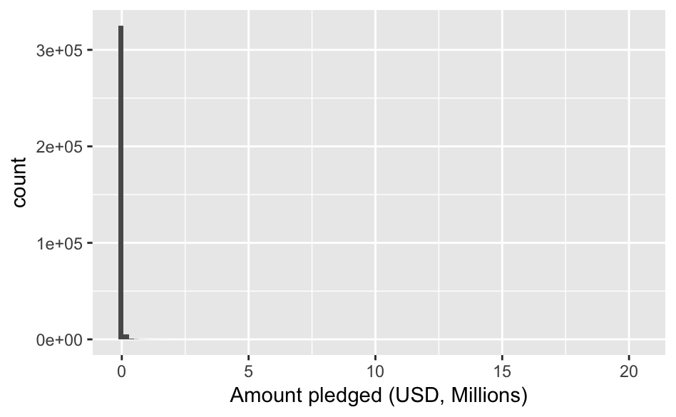

```r
ks18_2 %>% ggplot(aes(usd_pledged_real/1000000)) +
  geom_histogram(bins = 100, center = 1) +
  xlab("Amount pledged (USD, Millions)")
```

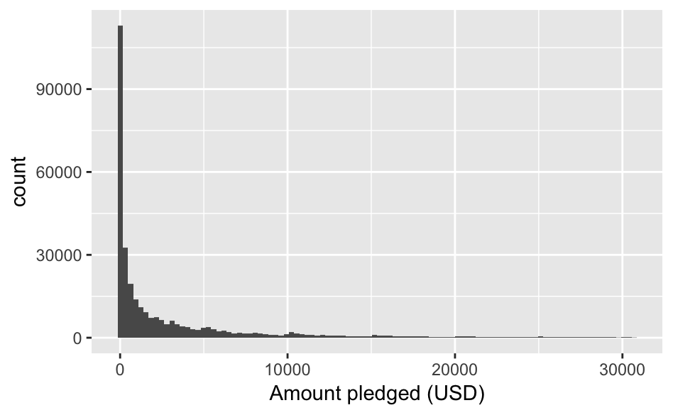

```r
pledge_q95 <- ks18_2$usd_pledged_real %>% quantile(0.95)
ks18_2 %>% filter(usd_pledged_real <= pledge_q95) %>%
  ggplot(aes(usd_pledged_real)) +
  geom_histogram(bins = 100, center = 1) +
  xlab("Amount pledged (USD)")
```

Filtering out observations where the amount pledged is above the 95th percentile (30694 USD).

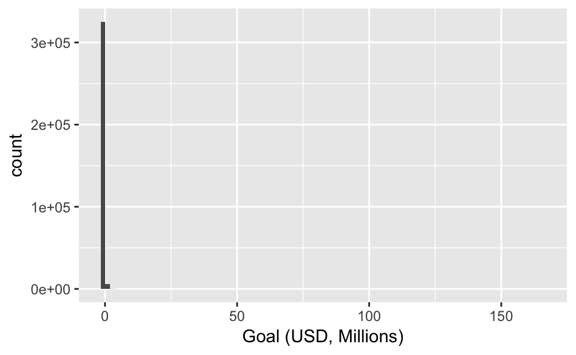

```r
ks18_2 %>% ggplot(aes(usd_goal_real/1000000)) +
  geom_histogram(bins = 100, center = 1) +
  xlab("Goal (USD, Millions)")
```

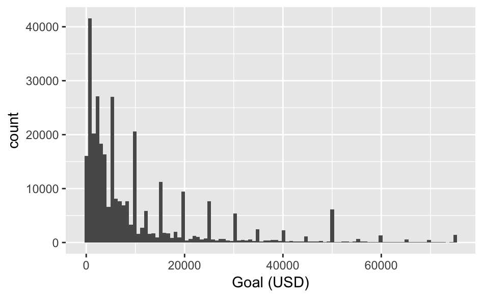

```r
goal_q95 <- ks18_2$usd_goal_real %>% quantile(0.95)
ks18_2 %>% filter(usd_goal_real <= goal_q95) %>%
  ggplot(aes(usd_goal_real)) +
  geom_histogram(bins = 100, center = 1) +
  xlab("Goal (USD)")
```

Filtering out observations where the goal is above the 95th percentile (75000 USD).

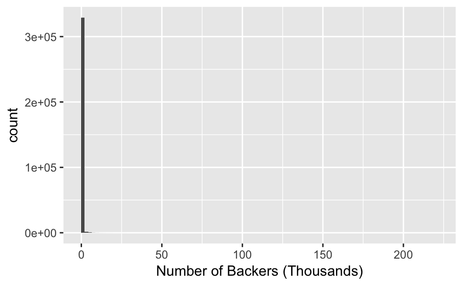

```r
ks18_2 %>% ggplot(aes(backers/1000)) +
  geom_histogram(bins = 100, center = 1) +
  xlab("Number of Backers (Thousands)")
```

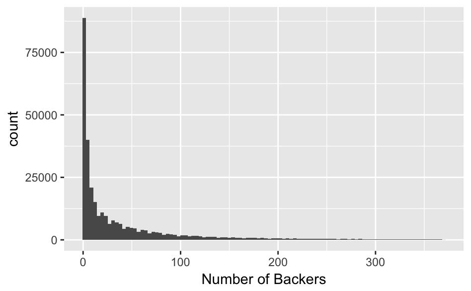

```r
backers_q95 <- ks18_2$backers %>% quantile(0.95)
ks18_2 %>% filter(backers <= backers_q95) %>%
  ggplot(aes(backers)) +
  geom_histogram(bins = 100, center = 1) +
  xlab("Number of Backers")
```

Filtering out observations where the number of backers is above the 95th percentile (369 backers).

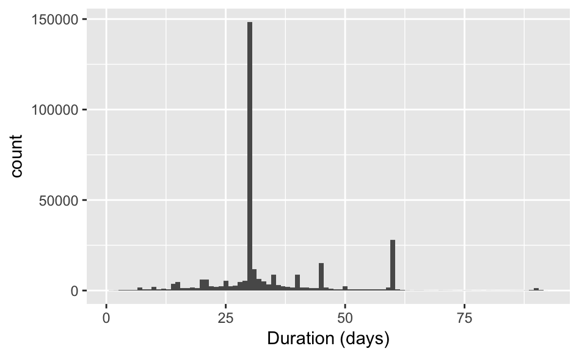

```r
ks18_2 %>% ggplot(aes(duration)) +
  geom_histogram(binwidth = 1, center = 1) +
  xlab("Duration (days)")
```

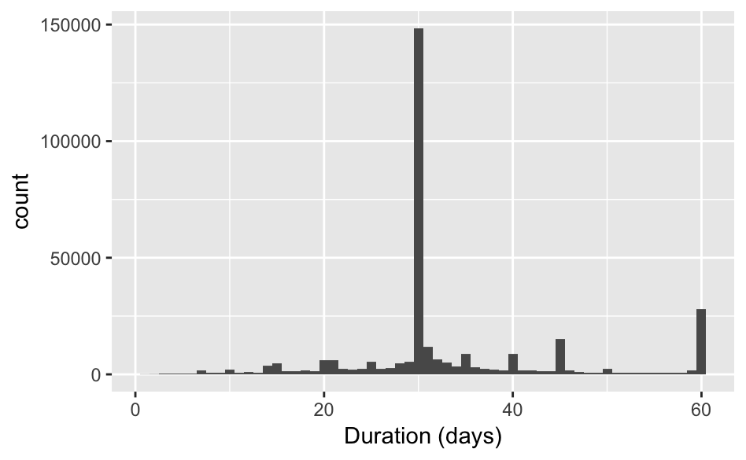

```r
duration_q95 <- ks18_2$duration %>% quantile(0.95)
ks18_2 %>% filter(duration <= duration_q95) %>%
  ggplot(aes(duration)) +
  geom_histogram(binwidth = 1, center = 1) +
  xlab("Duration (days)")
```

Filtering out observations where the duration is above the 95th percentile (60 days).

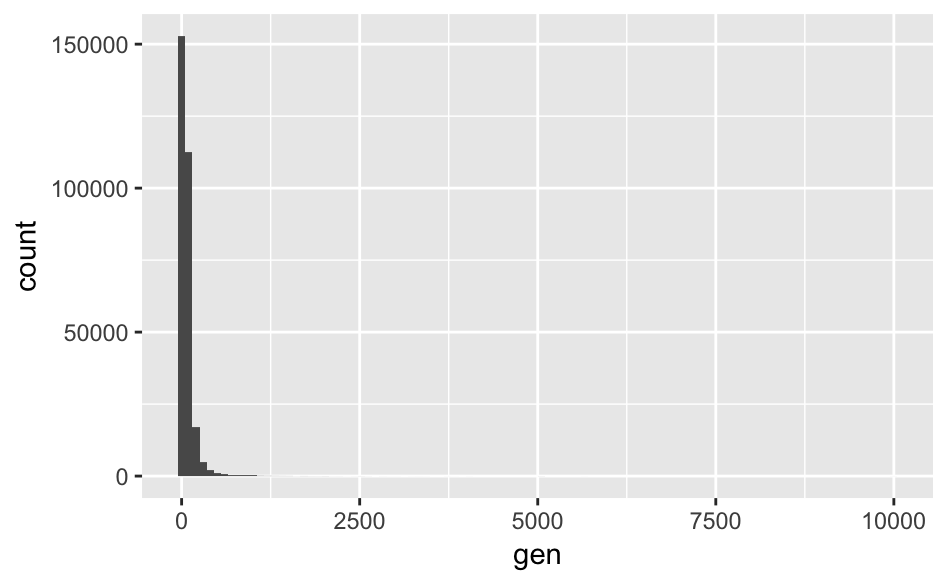

```r
ks18_2 %>%
  filter(gen != Inf & !is.nan(gen)) %>%
  ggplot(aes(gen)) +
  geom_histogram(bins = 100)
```

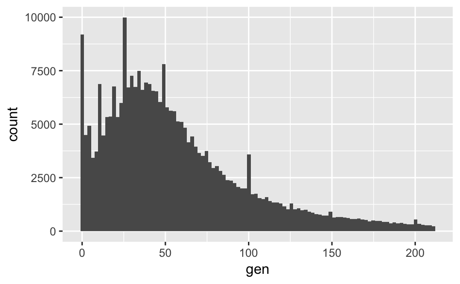

```r
gen_q95 <- ks18_2 %>%
  filter(gen != Inf & !is.nan(gen)) %>%
  pull(gen) %>% quantile(0.95)
ks18_2 %>%
  filter(gen != Inf & !is.nan(gen)) %>%
  filter(gen <= gen_q95) %>%
  ggplot(aes(gen)) +
  geom_histogram(bins = 100)
```

I filtered out the values of generosity that were NaN or Inf, then I filtered out the values that were above the 95th percentile (211$/backer)

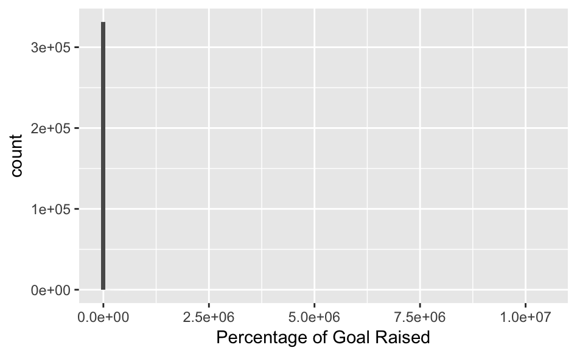

```r
ks18_2 %>% ggplot(aes(pct_raised)) +
  geom_histogram(bins = 100, center = 1) +
  xlab("Percentage of Goal Raised")
```

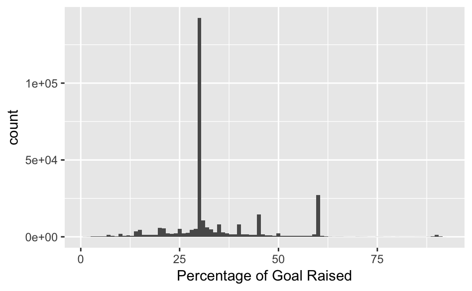

```r
pctr_q95 <- ks18_2$pct_raised %>% quantile(0.95)
ks18_2 %>% filter(pct_raised <= pctr_q95) %>%
  ggplot(aes(duration)) +
  geom_histogram(binwidth = 1, center = 1) +
  xlab("Percentage of Goal Raised")
```

```r
ks18_3 <- ks18_2 %>%
filter(usd_pledged_real <= pledge_q95) %>%
  filter(usd_goal_real <= goal_q95) %>%
  filter(backers <= backers_q95) %>%
  filter(duration <= duration_q95) %>%
  filter(gen != Inf & !is.nan(gen) & gen <= gen_q95) %>%
  filter(pct_raised <= pctr_q95)

(nrow(ks18_2) - nrow(ks18_3))/nrow(ks18_2)
```

```
[1] 0.2796412
```

Now I will see how the spread of data looks in the filtered dataset, called ks18_3

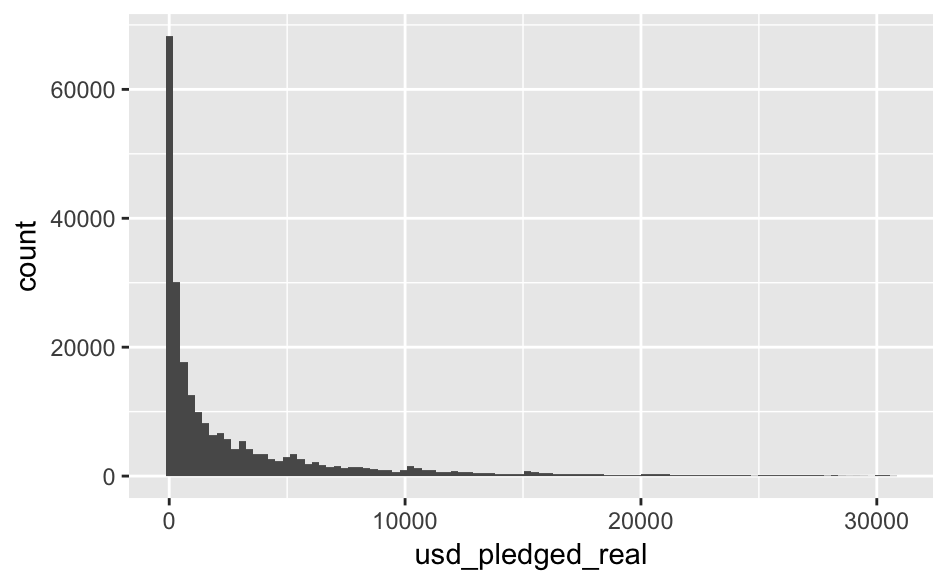

```r
ks18_3 %>% ggplot(aes(usd_pledged_real)) +
  geom_histogram(bins = 100)
```

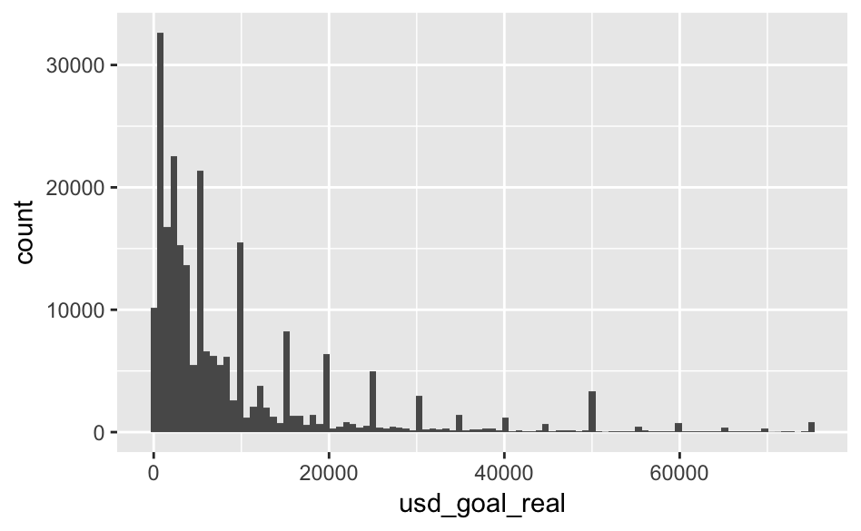

```r
ks18_3 %>% ggplot(aes(usd_goal_real)) +
  geom_histogram(bins = 100)
```

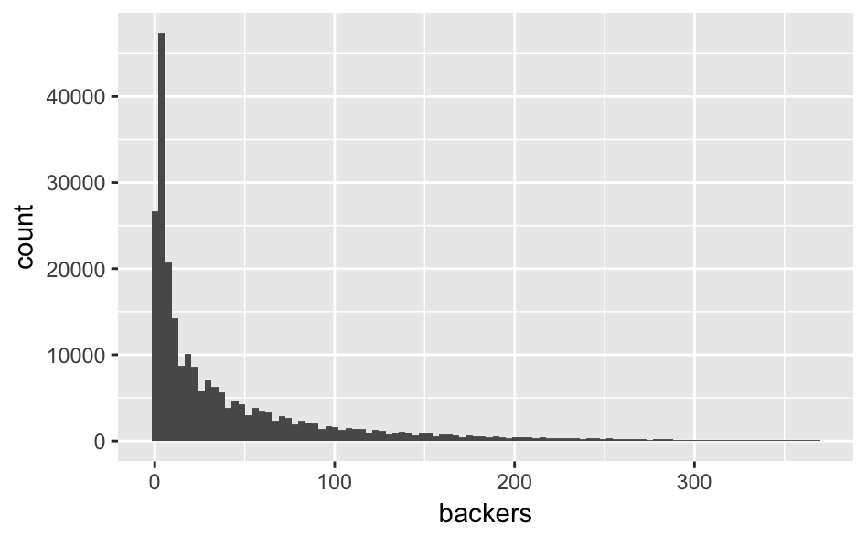

```r
ks18_3 %>% ggplot(aes(backers)) +
  geom_histogram(bins = 100)
```

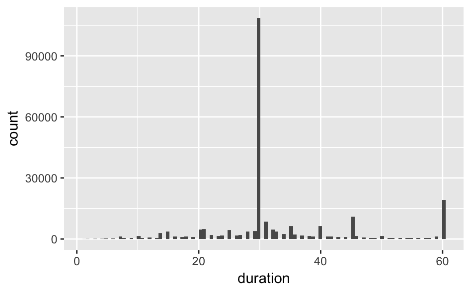

```r
ks18_3 %>% ggplot(aes(duration)) +
  geom_histogram(bins = 100)
```

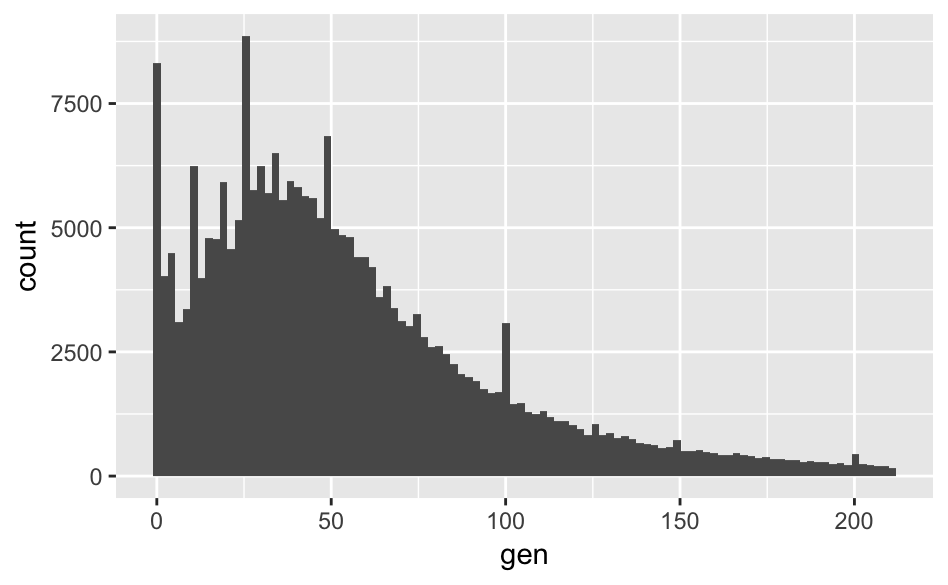

```r
ks18_3 %>% ggplot(aes(gen)) +
  geom_histogram(bins = 100)
```

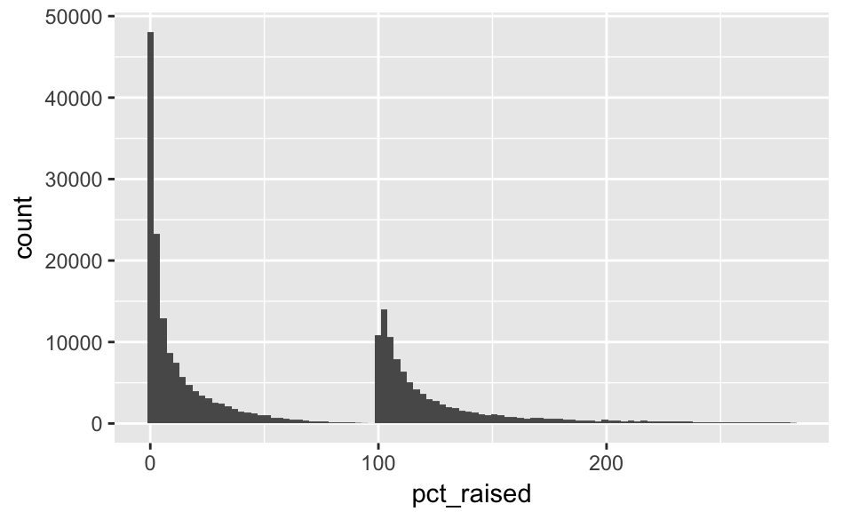

```r
ks18_3 %>% ggplot(aes(pct_raised)) +
  geom_histogram(bins = 100)
```

# Visualising the Data

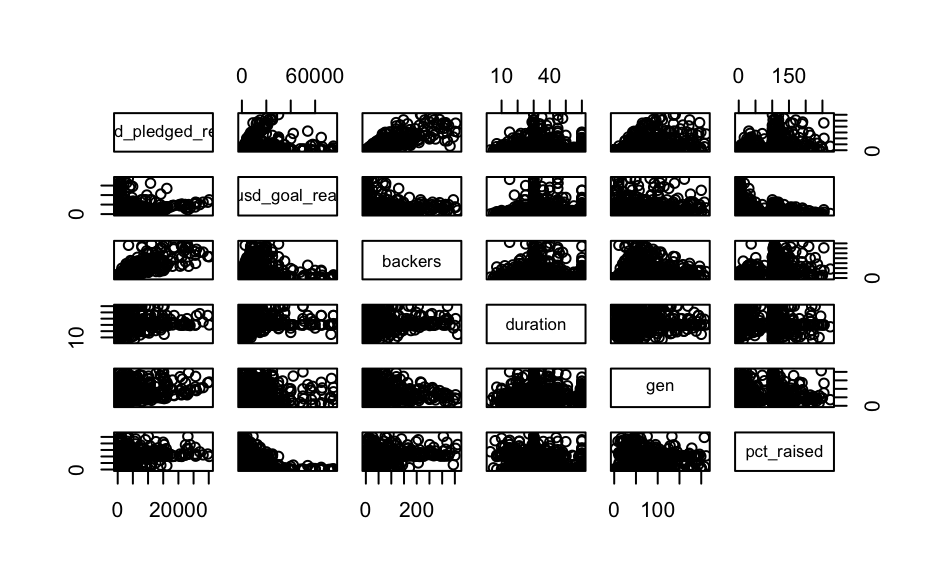

```r
ks18_3 %>%
  sample_n(1000) %>%
  select(usd_pledged_real, usd_goal_real, backers, duration, gen, pct_raised) %>%
  pairs()
```

There is some positive correlation between amount pledged and goal, amount pledged and number of backers. There is some negative correlation between the goal and the number of backers. There is some negative correlation between the number of backers and the generosity. (This is to be expected because generosity was calculated from the number of backers)

Now I will see how the data split according to the percentage of the goal raised.

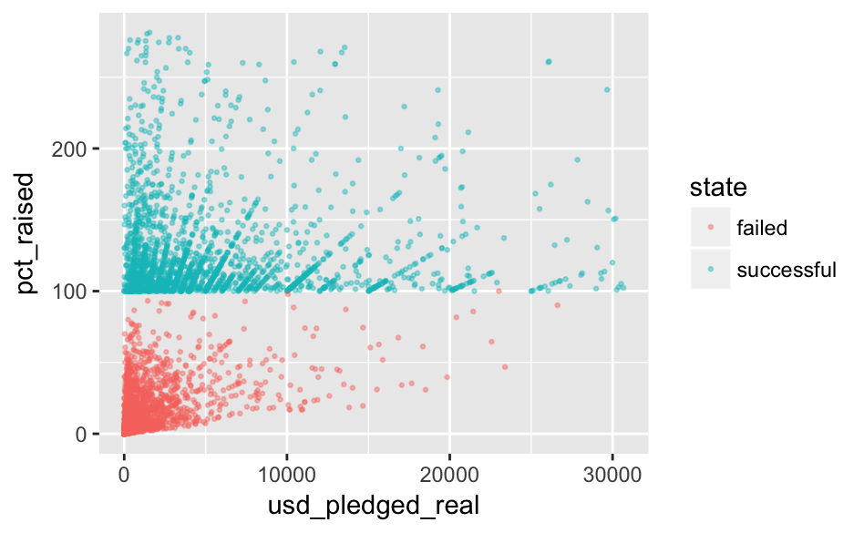

```r
ks18_3 %>% sample_n(5000) %>%
  ggplot(aes(usd_pledged_real, pct_raised, col = state)) +
  geom_point(size = 0.5, alpha = 0.4)
```

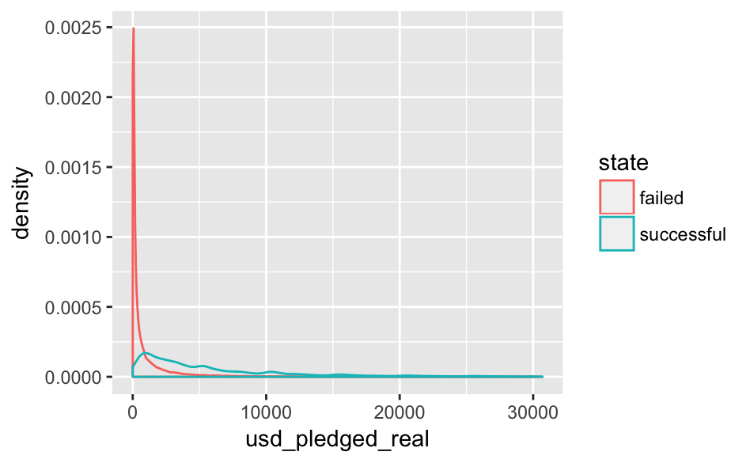

```r
ks18_3 %>%
  ggplot(aes(usd_pledged_real, col = state)) +
  geom_density()
```

Most of the failed projects do not raise close to 100% of their goal. There are some lines of strong positive correlation. These are for example, goals set to 10,000. Receiving pledges of 15,000 means the pct_raised is 150%. I think we see these strong correlations because pcr_raised was calculated from the amount pledged and therefore x is always correlated to y.

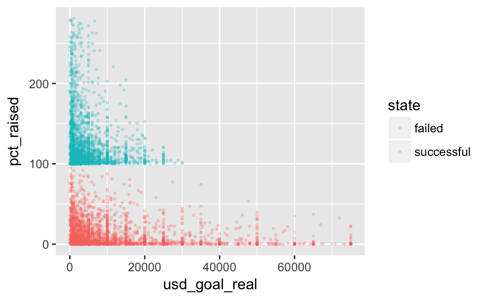

```r
ks18_3 %>% sample_n(5000) %>%
  ggplot(aes(usd_goal_real, pct_raised, col = state)) +
  geom_point(size = 0.5, alpha = 0.2)
```

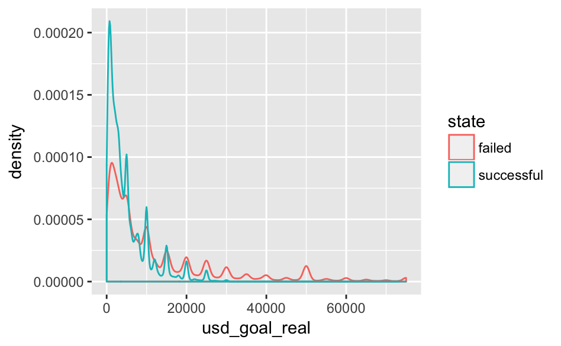

```r
ks18_3 %>%
  ggplot(aes(usd_goal_real, col = state)) +
  geom_density()
```

Most of the failed projects do not raise close to 100% of their goal. The strong lines indicate goal amounts. People tend to choose round numbers as goal amounts such as 10,000 or 20,000. There is some negative correlation between the goal and the percentage of goal raised for both failed and successful projects.

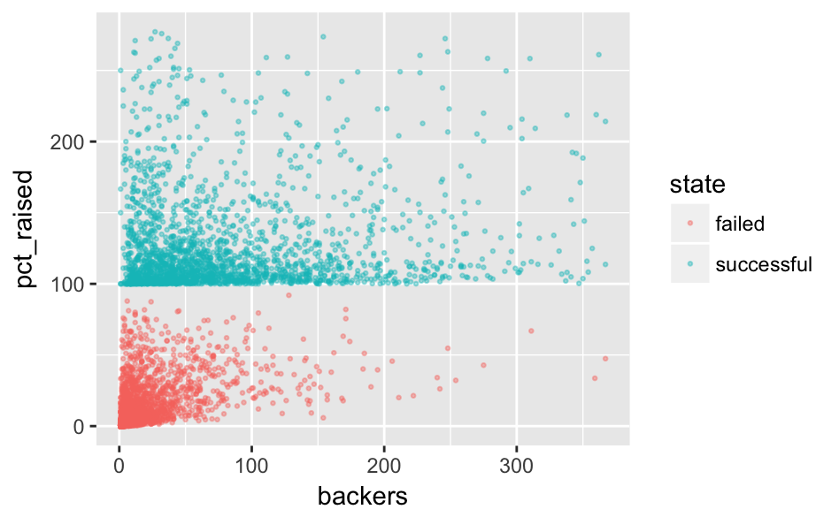

```r
ks18_3 %>% sample_n(5000) %>%
  ggplot(aes(backers, pct_raised, col = state)) +
  geom_point(size = 0.5, alpha = 0.4)
```

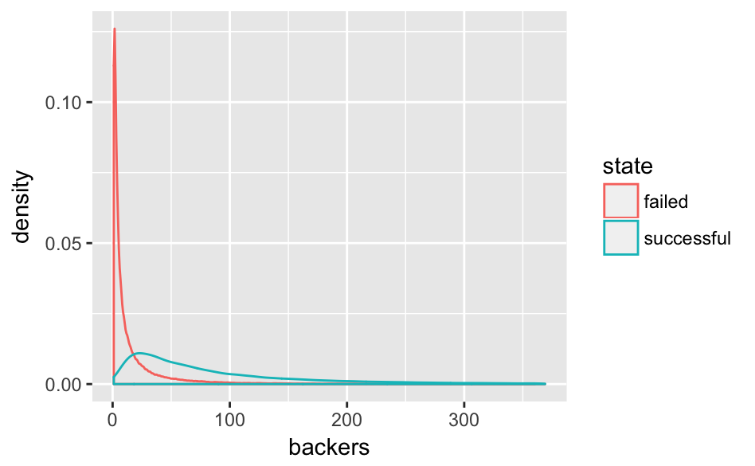

```r
ks18_3 %>%
  ggplot(aes(backers, col = state)) +
  geom_density()
```

Most of the failed projects do not raise close to 100% of their goal. There are no strong lines of correlation. Successful projects tend to have more backers than unsuccessful projects. Projects with more backers don’t necessarily raise more than ones with fewer backers.

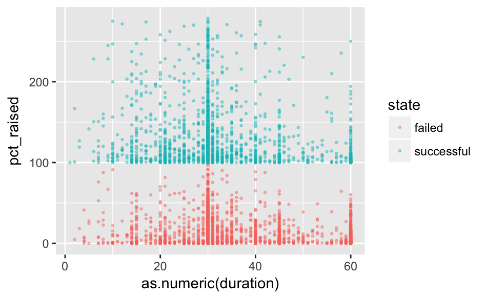

```r
ks18_3 %>% sample_n(5000) %>%
  ggplot(aes(as.numeric(duration), pct_raised, col = state)) +
  geom_point(size = 0.5, alpha = 0.4)
```

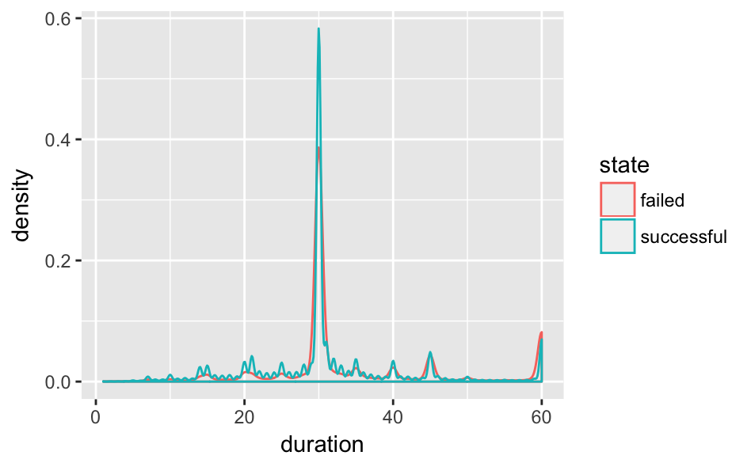

```r
ks18_3 %>%
  ggplot(aes(duration, col = state)) +
  geom_density()
```

Both successful and unsuccessful projects have a similar spread of durations.

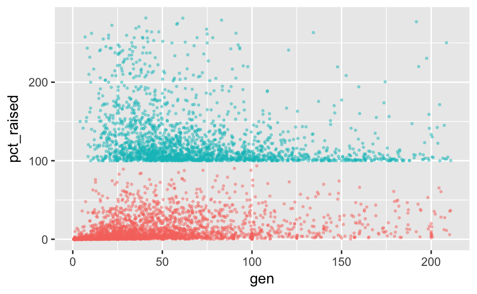

```r
ks18_3 %>% sample_n(5000) %>%
  ggplot(aes(gen, pct_raised, col = state)) +
  geom_point(size = 0.5, alpha = 0.4) +
  theme(legend.position = "none")
```

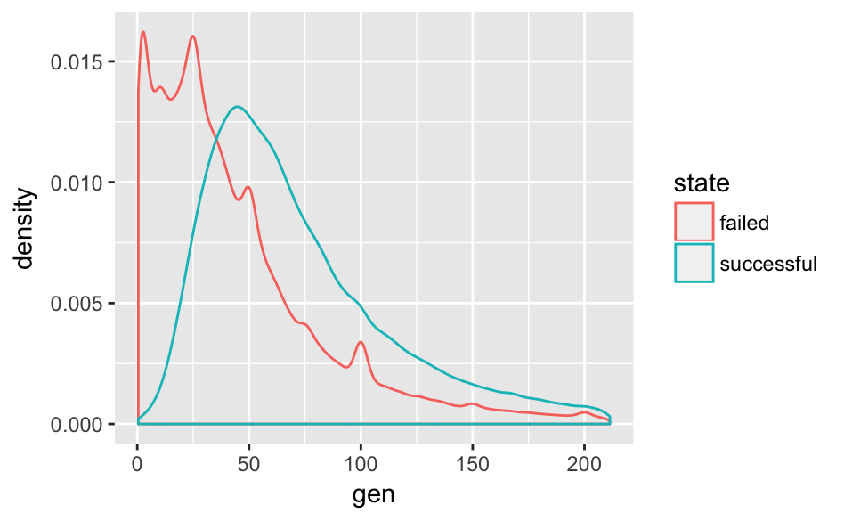

```r
ks18_3 %>%
  ggplot(aes(gen, col = state)) +
  geom_density()
```

Successful projects tend to have slightly more generous backers than thpse for unsuccessful projects.

# Predicting Success State using Caret

Afterwards I might try to predict pct_goal_raised.

ks18_2 has been mutated to add columns but has only been filtered to select “successful” and “failed” projects. Rather than using the trimmed dataset for the prediction, I will use the full dataset but preprocess the data by 1) creating dummy variables for the categories, 2) normalising to account for the right-tailed skew and 3) scaling the data because some columns have large values (such as goal) and others have small values (such as duration). The only further filtering I will do before pre-processing is the remove generosities with either NaN of Inf.

Yeo-Johnson is chosen as the normalisation method because it can tolerate zeros and negative values, but Box-Cox cannot. Other preprocessing could be nearZeoVar, findCorrelation, findLinearCombos. For these three I will first check to see which values would be excluded before deciding whether to include them in the actual preprocessing step.

**Selecting Features**

```r
ks18_4 <- ks18_2 %>% filter(gen != Inf & !is.nan(gen)) %>%
  select(state, category, main_category, goal, backers, usd_pledged_real, usd_goal_real, duration, endday, startday, endmonth, startmonth, gen)
ks18_4$state <- factor(ks18_4$state)
```

I removed the generosities with either NaN of Inf and only selected the features of interest (category, main_category, goal, state, backers, usd_pledged_real, usd_goal_real, duration, endday, startday, endmonth, startmonth, gen). I moved “state” to the first row for ease.

Features of interest are those that are not unique or proxies for the varible I want to predict e.g. pct_raised is a proxy for success state.

**Creating the Dummy Variables**

```r
dummyObj <- dummyVars(~ ., data = ks18_4, contrasts = FALSE)
k4_1 <- predict(dummyObj, newdata = ks18_4) %>% as.tibble()
glimpse(k4_1)
```

```
Observations: 292,828
Variables: 216
$ state.failed                  <dbl> 1, 1, 1, 0, 0, 1, 0,...
$ state.successful              <dbl> 0, 0, 0, 1, 1, 0, 1,...
$ `category.3D Printing`        <dbl> 0, 0, 0, 0, 0, 0, 0,...
$ category.Academic             <dbl> 0, 0, 0, 0, 0, 0, 0,...
$ category.Accessories          <dbl> 0, 0, 0, 0, 0, 0, 0,...
$ category.Action               <dbl> 0, 0, 0, 0, 0, 0, 0,...
$ category.Animals              <dbl> 0, 0, 0, 0, 0, 0, 0,...
$ category.Animation            <dbl> 0, 0, 0, 0, 0, 0, 0,...
$ category.Anthologies          <dbl> 0, 0, 0, 0, 0, 0, 0,...
$ category.Apparel              <dbl> 0, 0, 0, 0, 0, 0, 0,...
$ category.Apps                 <dbl> 0, 0, 0, 0, 0, 0, 0,...
$ category.Architecture         <dbl> 0, 0, 0, 0, 0, 0, 0,...
$ category.Art                  <dbl> 0, 0, 0, 0, 0, 0, 0,...
```

[output cut: 203 more lines]

I created dummy variables for the categorical variables. The unordered categorical values are now 1 and 0 e.g. Category.

```r
ks18_4$endday %>% head(8)
```

```
[1] Wed Tue Mon Fri Sun Thu Mon Wed
Levels: Mon < Tue < Wed < Thu < Fri < Sat < Sun
```

```r
k4_1[, 180:185]
```

| usd_goal_real | duration | endday.L | endday.Q | endday.C | endday^4 |
| --- | --- | --- | --- | --- | --- |
| 30000.00 | 60 | -1.889822e-01 | -3.273268e-01 | 4.082483e-01 | 0.0805823 |
| 45000.00 | 45 | -3.779645e-01 | 9.690821e-17 | 4.082483e-01 | -0.5640761 |
| 5000.00 | 30 | -5.669467e-01 | 5.455447e-01 | -4.082483e-01 | 0.2417469 |
| 50000.00 | 35 | 1.889822e-01 | -3.273268e-01 | -4.082483e-01 | 0.0805823 |
| 1000.00 | 20 | 5.669467e-01 | 5.455447e-01 | 4.082483e-01 | 0.2417469 |
| 25000.00 | 45 | 2.098124e-17 | -4.364358e-01 | 3.021644e-17 | 0.4834938 |
| 12500.00 | 30 | -5.669467e-01 | 5.455447e-01 | -4.082483e-01 | 0.2417469 |
| 6469.73 | 28 | -1.889822e-01 | -3.273268e-01 | 4.082483e-01 | 0.0805823 |
| 2500.00 | 30 | 3.779645e-01 | 0.000000e+00 | -4.082483e-01 | -0.5640761 |
| 1500.00 | 30 | 3.779645e-01 | 0.000000e+00 | -4.082483e-01 | -0.5640761 |

[output cut: 990 more lines]

```r
sum(k4_1[1, 180:185])
```

```
[1] 30059.97
```

```r
sum(k4_1[2, 180:185])
```

```
[1] 45044.47
```

```r
sum(k4_1[3, 180:185])
```

```
[1] 5029.812
```

```r
sum(k4_1[4, 180:185])
```

```
[1] 50034.53
```

```r
sum(k4_1[5, 180:185])
```

```
[1] 1021.762
```

```r
sum(k4_1[6, 180:185])
```

```
[1] 25045.05
```

```r
sum(k4_1[7, 180:185])
```

```
[1] 12529.81
```

```r
sum(k4_1[8, 180:185])
```

```
[1] 6497.703
```

Note that e.g. endday now is split into 6 columns. I thought these would be logical but they are not. However, summing the values over all endday columns gives a value that is different for each end day e.g. Monday is -0.2651147 and Wednesday is -0.079559. Therefore, these columns relate to the original column.

**Selecting Features Part II**

```r
k4_2 <- cbind(ks18_4$state, k4_1[ , -c(1,2)])
head(k4_2)
```

|  | ks18_4$state | category.3D Printing | category.Academic | category.Accessories | category.Action | category.Animals | category.Animation | category.Anthologies | category.Apparel | category.Apps | category.Architecture | category.Art | category.Art Books | category.Audio | category.Bacon | category.Blues | category.Calendars | category.Camera Equipment | category.Candles | category.Ceramics | category.Children's Books | category.Childrenswear | category.Chiptune | category.Civic Design | category.Classical Music | category.Comedy | category.Comic Books | category.Comics | category.Community Gardens | … |
| --- | --- | --- | --- | --- | --- | --- | --- | --- | --- | --- | --- | --- | --- | --- | --- | --- | --- | --- | --- | --- | --- | --- | --- | --- | --- | --- | --- | --- | --- | --- |
| 1 | failed | 0 | 0 | 0 | 0 | 0 | 0 | 0 | 0 | 0 | 0 | 0 | 0 | 0 | 0 | 0 | 0 | 0 | 0 | 0 | 0 | 0 | 0 | 0 | 0 | 0 | 0 | 0 | 0 | … |
| 2 | failed | 0 | 0 | 0 | 0 | 0 | 0 | 0 | 0 | 0 | 0 | 0 | 0 | 0 | 0 | 0 | 0 | 0 | 0 | 0 | 0 | 0 | 0 | 0 | 0 | 0 | 0 | 0 | 0 | … |
| 3 | failed | 0 | 0 | 0 | 0 | 0 | 0 | 0 | 0 | 0 | 0 | 0 | 0 | 0 | 0 | 0 | 0 | 0 | 0 | 0 | 0 | 0 | 0 | 0 | 0 | 0 | 0 | 0 | 0 | … |
| 4 | successful | 0 | 0 | 0 | 0 | 0 | 0 | 0 | 0 | 0 | 0 | 0 | 0 | 0 | 0 | 0 | 0 | 0 | 0 | 0 | 0 | 0 | 0 | 0 | 0 | 0 | 0 | 0 | 0 | … |
| 5 | successful | 0 | 0 | 0 | 0 | 0 | 0 | 0 | 0 | 0 | 0 | 0 | 0 | 0 | 0 | 0 | 0 | 0 | 0 | 0 | 0 | 0 | 0 | 0 | 0 | 0 | 0 | 0 | 0 | … |
| 6 | failed | 0 | 0 | 0 | 0 | 0 | 0 | 0 | 0 | 0 | 0 | 0 | 0 | 0 | 0 | 0 | 0 | 0 | 0 | 0 | 0 | 0 | 0 | 0 | 0 | 0 | 0 | 0 | 0 | … |

```r
names(k4_2)[1] <- "state"
```

I bound the dummy variables to the first column of the original dataframe because caret gave an error than if my predicted variable has only 2 values then I should use a 2 level factor instead.

Note: I think the order of the columns is in the order of the original factor levels (alphabetical in most cases unless otherwise specified by ordering or manual assignment).

**Checking how data would be affected by different pre-processing steps**

```r
nzv <- nearZeroVar(k4_2)
names(k4_2)[nzv]
```

```
  [1] "category.3D Printing"
  [2] "category.Academic"
  [3] "category.Accessories"
  [4] "category.Action"
  [5] "category.Animals"
  [6] "category.Animation"
  [7] "category.Anthologies"
  [8] "category.Apparel"
  [9] "category.Apps"
 [10] "category.Architecture"
 [11] "category.Art"
 [12] "category.Art Books"
 [13] "category.Audio"
 [14] "category.Bacon"
 [15] "category.Blues"
```

[output cut: 149 more lines]

Now I will check for near Zero variance. All the non-ordered categories have near zero variance because they only one category has a 1 per observation. Not sure how to deal with this.

```r
correl4_2 <- cor(k4_2[ , 2:ncol(k4_2)])
high_correl4_2 <- findCorrelation(correl4_2, cutoff = 0.9)
names(k4_2)[high_correl4_2]
```

```
[1] "main_category.Theater"
```

Now I will check for correlated columns, then create a vector of features. Then I identified highly correlated columns with a correlation cutoff of 0.9.

From the documentation “The absolute values of pair-wise correlations are considered. If two variables have a high correlation, the function looks at the mean absolute correlation of each variable and removes the variable with the largest mean absolute correlation.” So col 175 (main_category.Theater) had the most correlation with other variables.

I will not filter the table but just note this information. If needed, I can add it back as a preprocessing step.

**Pre-Processing**

```r
preProcObj <- preProcess(k4_2[, -1], method = c("scale", "YeoJohnson"))
k4_3 <- predict(preProcObj, k4_2)
k4_3 %>% select(category.Animation) %>% arrange(desc(category.Animation))
```

| category.Animation |
| --- |
| 12.43547 |
| 12.43547 |
| 12.43547 |
| 12.43547 |
| 12.43547 |
| 12.43547 |
| 12.43547 |
| 12.43547 |
| 12.43547 |
| 12.43547 |

[output cut: 990 more lines]

```r
summary(k4_2$category.Animation)
```

```
    Min.  1st Qu.   Median     Mean  3rd Qu.     Max.
0.000000 0.000000 0.000000 0.006509 0.000000 1.000000
```

```r
summary(k4_2$category.Animals)
```

```
    Min.  1st Qu.   Median     Mean  3rd Qu.     Max.
0.000000 0.000000 0.000000 0.000683 0.000000 1.000000
```

```r
summary(k4_2$state.successful)
```

```
Length  Class   Mode
     0   NULL   NULL
```

```r
summary(k4_3$category.Animation)
```

```
    Min.  1st Qu.   Median     Mean  3rd Qu.     Max.
 0.00000  0.00000  0.00000  0.08094  0.00000 12.43547
```

```r
summary(k4_3$category.Animals)
```

```
    Min.  1st Qu.   Median     Mean  3rd Qu.     Max.
 0.00000  0.00000  0.00000  0.02614  0.00000 38.27709
```

```r
summary(k4_3$state.successful)
```

```
Length  Class   Mode
     0   NULL   NULL
```

```r
unique(k4_2$category.Animation)
```

```
[1] 0 1
```

```r
unique(k4_2$category.Animals)
```

```
[1] 0 1
```

```r
unique(k4_2$state.successful)
```

```r
unique(k4_3$category.Animation)
```

```
[1]  0.00000 12.43547
```

```r
unique(k4_3$category.Animals)
```

```
[1]  0.00000 38.27709
```

```r
unique(k4_3$state.successful)
```

Now I will preprocess the data (which was already preprocessed to create dummy vars for the catgories). First I create the preprocessing object. I will use the “YeoJohnson” and “scale” methods. When looking at the object, in the method list I saw that “scale” was performed on all columns but “YeoJohnson” was only performed on the numerical ones (including the ordered day and month columns).

Note: In the tibble resulting from applying the preprocessing object to k4_2, some of the 0 and 1 of the category columns have been covnverted to floaters but this is ok. Also, for the category columns, there are still only 2 values but rather that 0 and 1, the values are 0 and somthing other than 0, due to scaling.

**Splitting the Data**

```r
prop.table(table(k4_3fold1$state))
```

```
    failed successful
 0.5430328  0.4569672
```

```r
prop.table(table(k4_3fold1train$state))
```

```
    failed successful
  0.530004   0.469996
```

```r
prop.table(table(k4_3fold1test$state))
```

```
    failed successful
 0.5429788  0.4570212
```

**Defining the Train Control Object**

```r
trainControlObj <- trainControl(method = "cv", number = 5)
```

For this logistic regression I will use the “glm” method which does not have additional tuning parameters.

**Training the Model**

```r
k4_3mod <- train(state ~ ., data = k4_3fold1train, method = "glm")
```